# Inspecting raw LC-MS Data

Pietro Franceschi

2024-10-09

```r
library(xcms)
library(MsExperiment)
library(tidyverse)
library(plotly)
library(Spectra)
```

## Introduction

The objective of this demo is to make you familiar with the characteristics of LC-MS metabolomics data (both MS1 and MS2) by using two packages belonging to the `xcms` ecosystem.

Since its first release in 2006, `xcms` has been steadily growing as one of the standards for the analysis of LC(GC)-MS-(MS) metabolomics data.

In the last years a huge effort has been made to set up a full `xcms` centric ecosystem which now allows to:

- efficiently handle raw MS data
- create and integrate databases of standards to perform annotation
- use/handle the results of fragmentation experiments
- …

… so many thanks to the people that are working on that!

## The Data

For our demo we will use a subset of a dataset on wines which have been recently acquired at the Fondazione E. Mach in Italy. The dataset has been designed for training purposes and includes MS and DDA (MS2 e MS3) (in positive and negative polarity) acquisition of a 20 wines with the following characteristics:

- 2 colors: red (n=10), white (n=10)
- 12 varieties

The acquisition sequences included blanks, pooled QC and samples. Al data were acquired with a HPLC-LTQ-Orbitrap instrument. A set of standard injections is also available to illustrate the annotation strategy.

## Reading one injection

To understand how the data behaves, let’s start reading in the data coming from one injection

```r
raw_one <- readMsExperiment(
  spectraFiles = "../data/wines/x016_X_QC_X_4_NEG_DDA.mzML", mode = "ondisk")
```

Let’s look to the object

```r
raw_one
```

```
## Object of class MsExperiment
##  Spectra: MS1 (546) MS2 (546) MS3 (546)
##  Experiment data: 1 sample(s)
##  Sample data links:
##   - spectra: 1 sample(s) to 1638 element(s).
```

It is important that along the process one can be able to visualize the raw data, so let’s give a look to the structure of the R object we created.

Let’s first get the retention times where spectra were collected

```r
## method to extract the retention times
rtime(raw_one)[1:20]
```

```
##  [1] 0.6727 1.0629 1.5381 1.8932 2.3157 2.7924 3.1473 3.5692 4.0451 4.4018
## [11] 4.8222 5.2973 5.6518 6.0737 6.5510 6.9058 7.3267 7.8191 8.1741 8.5963
```

```r
## this gives the type of experiment of the
msLevel(spectra(raw_one))[1:10]
```

```
##  [1] 1 2 3 1 2 3 1 2 3 1
```

As you see, they are interleaved.

## Full Scans

Let’s now get out the full scans

```r
## I'm telling xcms to filter only scans acquired in "Full scan mode"
fs_raw <- raw_one %>% filterMsLevel(1)
```

```
## Filter spectra
```

```r
fs_raw
```

```
## Object of class MsExperiment
##  Spectra: MS1 (546)
##  Experiment data: 1 sample(s)
##  Sample data links:
##   - spectra: 1 sample(s) to 546 element(s).
```

We already now how the `rt` will look like, but what about `mz` and `intensity`

```r
rt <- rtime(fs_raw)
mz <- mz(spectra(fs_raw))
I <-  intensity(spectra(fs_raw))
```

And their structure …

```r
glimpse(mz[1:4])
```

```
## Formal class 'SimpleNumericList' [package "IRanges"] with 4 slots
##   ..@ elementType    : chr "numeric"
##   ..@ elementMetadata: NULL
##   ..@ metadata       : list()
##   ..@ listData       :List of 4
##   .. ..$ : num [1:367] 51.4 53.6 53.7 53.7 53.7 ...
##   .. ..$ : num [1:346] 53.1 53.7 53.7 53.7 53.7 ...
##   .. ..$ : num [1:385] 51.2 53.5 53.7 53.7 53.7 ...
##   .. ..$ : num [1:382] 50.9 51.4 51.6 52.2 53.7 ...
```

```r
glimpse(I[1:4])
```

```
## Formal class 'SimpleNumericList' [package "IRanges"] with 4 slots
##   ..@ elementType    : chr "numeric"
##   ..@ elementMetadata: NULL
##   ..@ metadata       : list()
##   ..@ listData       :List of 4
##   .. ..$ : num [1:367] 5796 4898 14954 12601 18832 ...
##   .. ..$ : num [1:346] 5549 9187 10296 10868 9178 ...
##   .. ..$ : num [1:385] 5259 5481 4976 17168 22202 ...
##   .. ..$ : num [1:382] 5210 6492 5209 5071 15069 ...
```

So both object are lists: for every scan we have a vector of `mz` and a vector of `I`: a spectrum. We have 3D data!

### Plot by hand

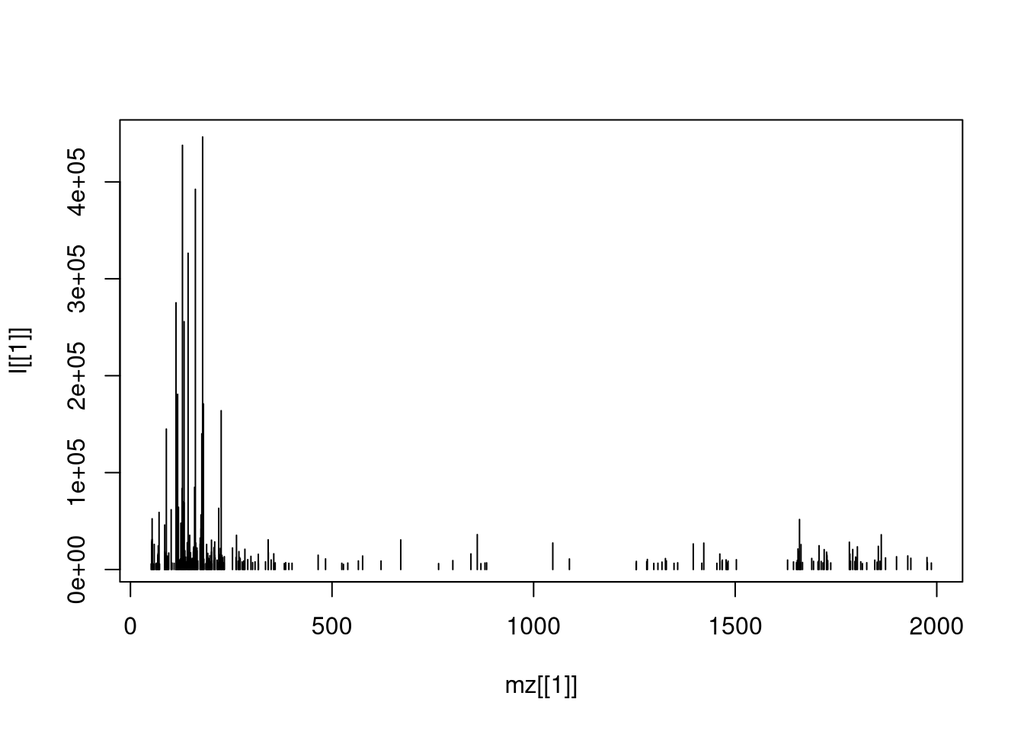

```r
plot(mz[[1]], I[[1]], type = "h")
```